# CITS4009 Project 2

WEI YANG 21220208

Introduction

The data set analyzed can be obtained from the Kaggle platform. This dataset was collected to work on NBA games data. I used the nba stats website to create this dataset. https://www.kaggle.com/nathanlauga/nba-games

The National Basketball Association (NBA) is an American men’s professional basketball league. It is composed of 30 teams and is one of the four major professional sports leagues in the United States and Canada. It is the premier men’s professional basketball league in the world.

In this project, 2 different model will be built to analyze the relationship between Technical Statistics and the final result of a game. This may help coach to adjust their strategy and help funs to predict a result before a match.

Also the performance of top players during the last 20 years will be clustered. So that we can identify type of players to known them better.

Data loading, overview and set up

Load libraries

```r
library(ggthemes)
library(grid)
library(ggplot2)
library(dplyr)
library(reshape2)
library(gridExtra)
library(rpart)
library(rpart.plot)
library(ROCR)
library(grid)
```

Setting up a plotting theme

```r
cits4009_theme <- theme(plot.title = element_text(color = "darkred"),
                        axis.text.y=element_text(size=8),
                        axis.title = element_text(color='black', vjust=0.1),legend.key.size=unit(.2,"inches"))
```

Load the main data

```r
nba<- read.csv("games_details.csv")
```

Using str to analyze the data

```r
str(nba)
```

```
'data.frame':   576782 obs. of  28 variables:
 $ GAME_ID          : int  21900895 21900895 21900895 21900895 21900895 21900895 21900895 21900895 21900895 21900895 ...
 $ TEAM_ID          : int  1610612749 1610612749 1610612749 1610612749 1610612749 1610612749 1610612749 1610612749 1610612749 1610612749 ...
 $ TEAM_ABBREVIATION: chr  "MIL" "MIL" "MIL" "MIL" ...
 $ TEAM_CITY        : chr  "Milwaukee" "Milwaukee" "Milwaukee" "Milwaukee" ...
 $ PLAYER_ID        : int  202083 203507 201572 1628978 202339 1626192 201577 1628425 101107 201588 ...
 $ PLAYER_NAME      : chr  "Wesley Matthews" "Giannis Antetokounmpo" "Brook Lopez" "Donte DiVincenzo" ...
 $ START_POSITION   : chr  "F" "F" "C" "G" ...
 $ COMMENT          : chr  "" "" "" "" ...
 $ MIN              : chr  "27:08" "34:55" "26:25" "27:35" ...
 $ FGM              : num  3 17 4 1 2 2 1 1 0 4 ...
 $ FGA              : num  11 28 11 5 8 5 5 2 1 11 ...
 $ FG_PCT           : num  0.273 0.607 0.364 0.2 0.25 0.4 0.2 0.5 0 0.364 ...
 $ FG3M             : num  2 1 1 0 0 1 0 1 0 1 ...
 $ FG3A             : num  7 4 5 3 1 4 0 2 1 4 ...
 $ FG3_PCT          : num  0.286 0.25 0.2 0 0 0.25 0 0.5 0 0.25 ...
 $ FTM              : num  0 6 7 0 0 1 0 0 0 2 ...
 $ FTA              : num  0 7 9 0 0 2 0 0 0 3 ...
 $ FT_PCT           : num  0 0.857 0.778 0 0 0.5 0 0 0 0.667 ...
 $ OREB             : num  4 2 2 1 1 2 1 0 0 2 ...
 $ DREB             : num  4 18 5 6 0 3 2 3 2 3 ...
 $ REB              : num  8 20 7 7 1 5 3 3 2 5 ...
 $ AST              : num  2 6 0 5 2 1 0 0 2 2 ...
 $ STL              : num  2 1 0 0 1 0 0 0 1 2 ...
 $ BLK              : num  0 0 3 1 0 0 1 0 1 0 ...
 $ TO               : num  0 3 0 2 3 1 2 1 1 3 ...
 $ PF               : num  0 2 2 0 2 2 1 0 1 1 ...
 $ PTS              : num  8 41 16 2 4 6 2 3 0 11 ...
 $ PLUS_MINUS       : num  11 22 16 14 6 0 -12 -8 -11 2 ...
```

Using summary to analyze the data

```r
summary(nba)
```

```
    GAME_ID            TEAM_ID          TEAM_ABBREVIATION   TEAM_CITY
 Min.   :10300001   Min.   :1.611e+09   Length:576782      Length:576782
 1st Qu.:20600629   1st Qu.:1.611e+09   Class :character   Class :character
 Median :21100461   Median :1.611e+09   Mode  :character   Mode  :character
 Mean   :21535815   Mean   :1.611e+09
 3rd Qu.:21600196   3rd Qu.:1.611e+09
 Max.   :41800406   Max.   :1.611e+09

   PLAYER_ID         PLAYER_NAME        START_POSITION       COMMENT
 Min.   :1.500e+01   Length:576782      Length:576782      Length:576782
 1st Qu.:2.366e+03   Class :character   Class :character   Class :character
 Median :2.008e+05   Mode  :character   Mode  :character   Mode  :character
 Mean   :2.794e+05
 3rd Qu.:2.027e+05
 Max.   :1.963e+09

     MIN                 FGM             FGA            FG_PCT           FG3M
 Length:576782      Min.   : 0.00   Min.   : 0.00   Min.   :0.00    Min.   : 0.00
 Class :character   1st Qu.: 1.00   1st Qu.: 3.00   1st Qu.:0.25    1st Qu.: 0.00
 Mode  :character   Median : 3.00   Median : 7.00   Median :0.43    Median : 0.00
                    Mean   : 3.56   Mean   : 7.86   Mean   :0.42    Mean   : 0.72
                    3rd Qu.: 5.00   3rd Qu.:11.00   3rd Qu.:0.56    3rd Qu.: 1.00
                    Max.   :28.00   Max.   :50.00   Max.   :1.00    Max.   :14.00
                    NA's   :92261   NA's   :92261   NA's   :92261   NA's   :92261
      FG3A          FG3_PCT           FTM             FTA            FT_PCT
 Min.   : 0.00   Min.   :0.00    Min.   : 0.00   Min.   : 0.00   Min.   :0.00
 1st Qu.: 0.00   1st Qu.:0.00    1st Qu.: 0.00   1st Qu.: 0.00   1st Qu.:0.00
 Median : 1.00   Median :0.00    Median : 1.00   Median : 2.00   Median :0.50
 Mean   : 2.02   Mean   :0.19    Mean   : 1.75   Mean   : 2.32   Mean   :0.44
 3rd Qu.: 3.00   3rd Qu.:0.33    3rd Qu.: 3.00   3rd Qu.: 4.00   3rd Qu.:0.91
 Max.   :24.00   Max.   :1.00    Max.   :26.00   Max.   :39.00   Max.   :1.00
 NA's   :92261   NA's   :92261   NA's   :92261   NA's   :92261   NA's   :92261
      OREB            DREB            REB             AST             STL
 Min.   : 0.00   Min.   : 0.00   Min.   : 0.00   Min.   : 0.00   Min.   : 0.00
 1st Qu.: 0.00   1st Qu.: 1.00   1st Qu.: 1.00   1st Qu.: 0.00   1st Qu.: 0.00
 Median : 1.00   Median : 2.00   Median : 3.00   Median : 1.00   Median : 0.00
 Mean   : 1.04   Mean   : 3.01   Mean   : 4.05   Mean   : 2.08   Mean   : 0.72
 3rd Qu.: 2.00   3rd Qu.: 4.00   3rd Qu.: 6.00   3rd Qu.: 3.00   3rd Qu.: 1.00
 Max.   :18.00   Max.   :25.00   Max.   :31.00   Max.   :25.00   Max.   :10.00
 NA's   :92261   NA's   :92261   NA's   :92261   NA's   :92261   NA's   :92261
      BLK              TO              PF             PTS          PLUS_MINUS
 Min.   : 0.00   Min.   : 0.00   Min.   : 0.00   Min.   : 0.0    Min.   :-57
 1st Qu.: 0.00   1st Qu.: 0.00   1st Qu.: 1.00   1st Qu.: 3.0    1st Qu.: -7
 Median : 0.00   Median : 1.00   Median : 2.00   Median : 8.0    Median :  0
 Mean   : 0.46   Mean   : 1.33   Mean   : 2.02   Mean   : 9.6    Mean   :  0
 3rd Qu.: 1.00   3rd Qu.: 2.00   3rd Qu.: 3.00   3rd Qu.:14.0    3rd Qu.:  6
 Max.   :12.00   Max.   :12.00   Max.   :15.00   Max.   :81.0    Max.   : 57
 NA's   :92261   NA's   :92261   NA's   :92261   NA's   :92261   NA's   :115922
```

Viewing the first six observations

```r
head(nba)
```

|  | GAME_ID | TEAM_ID | TEAM_ABBREVIATION | TEAM_CITY | PLAYER_ID | PLAYER_NAME | START_POSITION | COMMENT | MIN | FGM | FGA | FG_PCT | FG3M | FG3A | FG3_PCT | FTM | FTA | FT_PCT | OREB | DREB | REB | AST | STL | BLK | TO | PF | PTS | PLUS_MINUS |
| --- | --- | --- | --- | --- | --- | --- | --- | --- | --- | --- | --- | --- | --- | --- | --- | --- | --- | --- | --- | --- | --- | --- | --- | --- | --- | --- | --- | --- |
| 1 | 21900895 | 1610612749 | MIL | Milwaukee | 202083 | Wesley Matthews | F |  | 27:08 | 3 | 11 | 0.273 | 2 | 7 | 0.286 | 0 | 0 | 0.000 | 4 | 4 | 8 | 2 | 2 | 0 | 0 | 0 | 8 | 11 |
| 2 | 21900895 | 1610612749 | MIL | Milwaukee | 203507 | Giannis Antetokounmpo | F |  | 34:55 | 17 | 28 | 0.607 | 1 | 4 | 0.250 | 6 | 7 | 0.857 | 2 | 18 | 20 | 6 | 1 | 0 | 3 | 2 | 41 | 22 |
| 3 | 21900895 | 1610612749 | MIL | Milwaukee | 201572 | Brook Lopez | C |  | 26:25 | 4 | 11 | 0.364 | 1 | 5 | 0.200 | 7 | 9 | 0.778 | 2 | 5 | 7 | 0 | 0 | 3 | 0 | 2 | 16 | 16 |
| 4 | 21900895 | 1610612749 | MIL | Milwaukee | 1628978 | Donte DiVincenzo | G |  | 27:35 | 1 | 5 | 0.200 | 0 | 3 | 0.000 | 0 | 0 | 0.000 | 1 | 6 | 7 | 5 | 0 | 1 | 2 | 0 | 2 | 14 |
| 5 | 21900895 | 1610612749 | MIL | Milwaukee | 202339 | Eric Bledsoe | G |  | 22:17 | 2 | 8 | 0.250 | 0 | 1 | 0.000 | 0 | 0 | 0.000 | 1 | 0 | 1 | 2 | 1 | 0 | 3 | 2 | 4 | 6 |
| 6 | 21900895 | 1610612749 | MIL | Milwaukee | 1626192 | Pat Connaughton |  |  | 24:52 | 2 | 5 | 0.400 | 1 | 4 | 0.250 | 1 | 2 | 0.500 | 2 | 3 | 5 | 1 | 0 | 0 | 1 | 2 | 6 | 0 |

Show range of game_ID

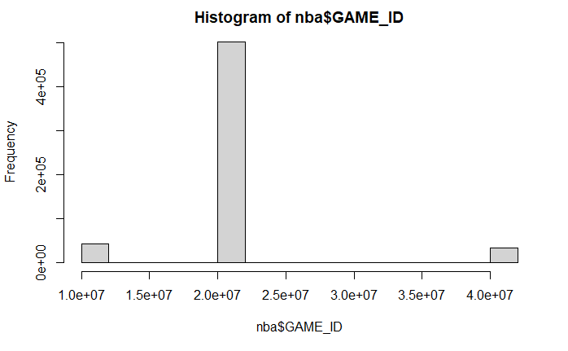

```r
hist(nba$GAME_ID)
```

DATA Procsssing

It can been seen that there are 3 types of games which are preseason,regular season and playoff. We only focus on regular season games.

Remove gameID start from 1 which are preseason

```r
nba<- nba[which(nba$GAME_ID>"20000000"&nba$GAME_ID<"40000000"),]
```

Add column of years of games

```r
year<-function(a){#write a function to generate year from GAMEID
    a1<-"20"
    a2<-substring(a,2,3)
    paste(a1,a2,sep="")
}
nba<-mutate(nba,year=year(GAME_ID))
```

Analyze the number of NA each variables

```r
apply(is.na(nba), 2, sum)
```

```
          GAME_ID           TEAM_ID TEAM_ABBREVIATION         TEAM_CITY
                0                 0                 0                 0
        PLAYER_ID       PLAYER_NAME    START_POSITION           COMMENT
                0                 0                 0                 0
              MIN               FGM               FGA            FG_PCT
                0             81768             81768             81768
             FG3M              FG3A           FG3_PCT               FTM
            81768             81768             81768             81768
              FTA            FT_PCT              OREB              DREB
            81768             81768             81768             81768
              REB               AST               STL               BLK
            81768             81768             81768             81768
               TO                PF               PTS        PLUS_MINUS
            81768             81768             81768             81768
             year
                0
```

```r
nba <- na.omit(nba)
```

Generate data for analysing. For the project I want to analyze the relationship between games strategy and the game results. How to predict if a team will win or loss in a particular match.Then the data was changed to required format.

```r
games1<-aggregate(nba[,c(10,11,13,14,16,17,19:27)],by=list(gameID=nba$GAME_ID),FUN=sum)
games<-aggregate(nba[,c(10,11,13,14,16,17,19:27)],by=list(gameID=nba$GAME_ID,Team =nba$TEAM_ABBREVIATION),FUN=sum)
games<-mutate(games,year=year(gameID))
col<-setdiff(colnames(games),list('year','gameID','Team'))
```

The data of opponent in a particular match is generated. So, more parameter can be add to a particular match. So that we have more option to choose from.

```r
total<-games
for(i in c(1:length(games$gameID))){
  vector<- games1[games1$gameID==games$gameID[i],]
  total$PTS[i] <- vector$PTS
  total$FGM[i]  <- vector$FGM
  total$FGA[i] <- vector$FGA
  total$FG3M[i] <- vector$FG3M
  total$FG3A[i] <- vector$FG3A
  total$FTM[i] <- vector$FTM
  total$FTA[i] <- vector$FTA
  total$OREB[i] <- vector$OREB
  total$DREB [i] <- vector$DREB
  total$REB [i] <- vector$REB
  total$AST[i] <- vector$AST
  total$STL[i] <- vector$STL
  total$BLK[i] <- vector$BLK
  total$TO[i] <- vector$TO
  total$PF[i] <- vector$PF
}
```

Add the target: game result in the data, later we will analize the relationship between the variables and the game results.

```r
difcol<-paste("Dif",col,sep='')
games[difcol]<-2*games[col]-total[col]
games<-mutate(games,TS=round(PTS/(2*(FGA+0.44*FTA)),3))
games<-mutate(games,FG_PCT=round(FGM/FGA,3))
games<-mutate(games,FG3_PCT=round(FG3M/FG3A,3))
games<-mutate(games,FT_PCT=round(FTM/FTA,3))
games$result <-ifelse(games$PTS>total$PTS/2,1,-1)
```

Classification

Firstly, I will conduct Single variable analysis. Separate the whole data set in two 3 part Train, Test and calibration. The outcome are set to be the result of a game and all other variables will be factors.

```r
set.seed(729375)
games$rgroup <- runif(dim(games)[[1]])
TrainAll <- subset(games,rgroup<=0.9)
Test <- subset(games,rgroup>0.9)
outcome <- 'result'
vars <- setdiff(colnames(TrainAll), c(outcome,'rgroup'))
catVars <- vars[sapply(TrainAll[,vars],class) %in%c('factor','character')]
numericVars <- vars[sapply(TrainAll[,vars],class) %in%c('numeric','integer')]
pos <- '1'
useForCal <- rbinom(n=dim(TrainAll)[[1]],size=1,prob=0.1)>0
Cal <- subset(TrainAll,useForCal)
Train <- subset(TrainAll,!useForCal)
```

This is the function to get the prediction from categorical variables.

```r
mkPredC <- function(outCol,varCol,appCol) {
pPos <- sum(outCol==pos)/length(outCol)
naTab <- table(as.factor(outCol[is.na(varCol)]))
pPosWna <- (naTab/sum(naTab))[pos]
vTab <- table(as.factor(outCol),varCol)
pPosWv <- (vTab[pos,]+1.0e-3*pPos)/(colSums(vTab)+1.0e-3)
pred <- pPosWv[appCol]
pred[is.na(appCol)] <- pPosWna
pred[is.na(pred)] <- pPos
pred
}
```

predict the realation between outcome and each single variable and add the result at the end of the data.

```r
for(v in catVars) {
pi <- paste('pred',v,sep='')
Train[,pi] <- mkPredC(Train[,outcome],
Train[,v],Train[,v])
Cal[,pi] <- mkPredC(Train[,outcome],
Train[,v],Cal[,v])
Test[,pi] <- mkPredC(Train[,outcome],
Train[,v],Test[,v])
}
```

Build a function to calculate the AUC of each single variables

```r
library('ROCR')
calcAUC <- function(predcol,outcol) {
perf <- performance(prediction(predcol,outcol==pos),'auc')
as.numeric(perf@y.values)
}
```

Print out the AUC for each categorical variables of both training and calibration data set

```r
for(v in catVars) {
pi <- paste('pred',v,sep='')
aucTrain <- calcAUC(Train[,pi],Train[,outcome])
if(aucTrain>=0.5) {
aucCal <- calcAUC(Cal[,pi],Cal[,outcome])
print(sprintf(
"%s, trainAUC: %4.3f calibrationAUC: %4.3f",
pi, aucTrain, aucCal))
}
}
```

```
[1] "predTeam, trainAUC: 0.579 calibrationAUC: 0.580"
[1] "predyear, trainAUC: 0.504 calibrationAUC: 0.475"
```

Bin the numeric feature into a number of ranges and then use the range labels as a new categorical variable.

```r
mkPredN <- function(outCol,varCol,appCol) {
cuts <- unique(as.numeric(
quantile(varCol, probs=seq(0, 1, 0.1),na.rm=T)))
varC <- cut(varCol,cuts)
appC <- cut(appCol,cuts)
mkPredC(outCol,varC,appC)
}
```

Print out the AUc of training and calibration set for all numerical variables

```r
for(v in numericVars) {
pi<-paste('pred',v,sep='')
Train[,pi]<-mkPredN(Train[,outcome],Train[,v],Train[,v])
Test[,pi]<-mkPredN(Train[,outcome],Train[,v],Test[,v])
Cal[,pi]<-mkPredN(Train[,outcome],Train[,v],Cal[,v])
aucTrain<-calcAUC(Train[,pi],Train[,outcome])
if(aucTrain>=0.55) {
aucCal<-calcAUC(Cal[,pi],Cal[,outcome])
print(sprintf(
"%s, trainAUC: %4.3f calibrationAUC: %4.3f",
pi,aucTrain,aucCal))
}
}
```

```
[1] "predFGM, trainAUC: 0.700 calibrationAUC: 0.704"
[1] "predFG3M, trainAUC: 0.604 calibrationAUC: 0.631"
[1] "predFTM, trainAUC: 0.594 calibrationAUC: 0.580"
[1] "predFTA, trainAUC: 0.579 calibrationAUC: 0.561"
[1] "predDREB, trainAUC: 0.691 calibrationAUC: 0.679"
[1] "predREB, trainAUC: 0.649 calibrationAUC: 0.639"
[1] "predAST, trainAUC: 0.681 calibrationAUC: 0.689"
[1] "predSTL, trainAUC: 0.578 calibrationAUC: 0.576"
[1] "predBLK, trainAUC: 0.595 calibrationAUC: 0.601"
[1] "predTO, trainAUC: 0.568 calibrationAUC: 0.579"
[1] "predPF, trainAUC: 0.571 calibrationAUC: 0.575"
[1] "predPTS, trainAUC: 0.745 calibrationAUC: 0.746"
[1] "predDifFGM, trainAUC: 0.851 calibrationAUC: 0.845"
[1] "predDifFG3M, trainAUC: 0.678 calibrationAUC: 0.693"
[1] "predDifFTM, trainAUC: 0.649 calibrationAUC: 0.633"
[1] "predDifFTA, trainAUC: 0.626 calibrationAUC: 0.607"
[1] "predDifDREB, trainAUC: 0.805 calibrationAUC: 0.788"
[1] "predDifREB, trainAUC: 0.715 calibrationAUC: 0.699"
[1] "predDifAST, trainAUC: 0.777 calibrationAUC: 0.778"
[1] "predDifSTL, trainAUC: 0.614 calibrationAUC: 0.619"
[1] "predDifBLK, trainAUC: 0.635 calibrationAUC: 0.640"
[1] "predDifTO, trainAUC: 0.605 calibrationAUC: 0.616"
[1] "predDifPF, trainAUC: 0.627 calibrationAUC: 0.610"
[1] "predDifPTS, trainAUC: 0.997 calibrationAUC: 0.996"
[1] "predTS, trainAUC: 0.773 calibrationAUC: 0.780"
[1] "predFG_PCT, trainAUC: 0.753 calibrationAUC: 0.757"
[1] "predFG3_PCT, trainAUC: 0.667 calibrationAUC: 0.679"
[1] "predFT_PCT, trainAUC: 0.553 calibrationAUC: 0.566"
```

Just by calculating the pose of each game and all data will transfer to per 100 posese. The rebound will be subsitute by rebound rate which is independent to other factors like field goal rate but only depends on the ability of rebound.

After reform the data set to do the calculation again

```r
games<-aggregate(nba[,c(10,11,13,14,16,17,19:27)],by=list(gameID=nba$GAME_ID,Team =nba$TEAM_ABBREVIATION),FUN=sum)
games<-mutate(games,year=year(gameID))

games[difcol]<-2*games[col]-total[col]
games<-mutate(games,TS=round(PTS/(2*(FGA+0.44*FTA)),3))
games<-mutate(games,FG_PCT=round(FGM/FGA,3))
games<-mutate(games,FG3_PCT=round(FG3M/FG3A,3))
games<-mutate(games,FT_PCT=round(FTM/FTA,3))
games$result <-ifelse(games$PTS>total$PTS/2,1,-1)
games<- mutate(games,A3P=round(FG3A/FGA,3))
games<- mutate(games,DREB_P=round(DREB/(DREB+OREB-DifOREB),3))
games<- mutate(games,OREB_P=round(OREB/(OREB+DREB-DifDREB),3))
games<-mutate(games,AST_P=round(AST/FGM,3))
games<-mutate(games,STL_P=round(STL/(FGA+FTA/2+TO)*100,3))
games<-mutate(games,BLK_P=round(BLK/(FGA+FTA/2+TO)*100,3))
games<-mutate(games,TO_P=round(TO/(FGA+FTA/2+TO)*100,3))
selcol <- c('Team','year','FTA','PF','AST_P','DifFG3A','A3P','DREB_P','OREB_P','TO_P','STL_P','BLK_P','result')
games<-games[selcol]
```

```r
set.seed(729375)
games$rgroup <- runif(dim(games)[[1]])
TrainAll <- subset(games,rgroup<=0.9)
Test <- subset(games,rgroup>0.9)
outcome <- 'result'
vars <- setdiff(colnames(TrainAll), c(outcome,'rgroup'))
catVars <- vars[sapply(TrainAll[,vars],class) %in%c('factor','character')]
numericVars <- vars[sapply(TrainAll[,vars],class) %in%c('numeric','integer')]
pos <- '1'
useForCal <- rbinom(n=dim(TrainAll)[[1]],size=1,prob=0.1)>0
Cal <- subset(TrainAll,useForCal)
Train <- subset(TrainAll,!useForCal)
t<-Train
```

```r
for(v in catVars) {
pi <- paste('pred',v,sep='')
Train[,pi] <- mkPredC(Train[,outcome],
Train[,v],Train[,v])
Cal[,pi] <- mkPredC(Train[,outcome],
Train[,v],Cal[,v])
Test[,pi] <- mkPredC(Train[,outcome],
Train[,v],Test[,v])
}

for(v in catVars) {
pi <- paste('pred',v,sep='')
aucTrain <- calcAUC(Train[,pi],Train[,outcome])
if(aucTrain>=0.5) {
aucCal <- calcAUC(Cal[,pi],Cal[,outcome])
print(sprintf(
"%s, trainAUC: %4.3f calibrationAUC: %4.3f",
pi, aucTrain, aucCal))
}
}
```

```
[1] "predTeam, trainAUC: 0.579 calibrationAUC: 0.580"
[1] "predyear, trainAUC: 0.504 calibrationAUC: 0.475"
```

```r
for(v in numericVars) {
pi<-paste('pred',v,sep='')
Train[,pi]<-mkPredN(Train[,outcome],Train[,v],Train[,v])
Test[,pi]<-mkPredN(Train[,outcome],Train[,v],Test[,v])
Cal[,pi]<-mkPredN(Train[,outcome],Train[,v],Cal[,v])
aucTrain<-calcAUC(Train[,pi],Train[,outcome])
if(aucTrain>=0.55) {
aucCal<-calcAUC(Cal[,pi],Cal[,outcome])
print(sprintf(
"%s, trainAUC: %4.3f calibrationAUC: %4.3f",
pi,aucTrain,aucCal))
}
}
```

```
[1] "predFTA, trainAUC: 0.579 calibrationAUC: 0.561"
[1] "predPF, trainAUC: 0.571 calibrationAUC: 0.575"
[1] "predAST_P, trainAUC: 0.580 calibrationAUC: 0.588"
[1] "predDREB_P, trainAUC: 0.560 calibrationAUC: 0.557"
[1] "predOREB_P, trainAUC: 0.563 calibrationAUC: 0.554"
[1] "predTO_P, trainAUC: 0.564 calibrationAUC: 0.575"
[1] "predSTL_P, trainAUC: 0.583 calibrationAUC: 0.586"
[1] "predBLK_P, trainAUC: 0.598 calibrationAUC: 0.605"
```

```r
train<-Train
train$result<-t$result
```

It is such a surprising found that blocking is the most influential factor of winning a game. Actually, blocking can not take a transition of ball like a steal, it just stop opponent shooting but can not guarantee to take the ball after a blocking. However, it took the lead even surpassing steal and turnovers which can not be simply describe by Statistics. The only explanation of that is blocking can boost morale and reverse the momentum of a game and deter and destroy opponent. So that your team can dominent the game.

Let us plot the Area under ROC curve for blocking

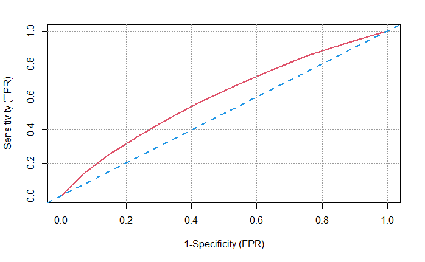

```r
library(ROCit)
plot_roc <- function(predcol, outcol){
ROCit_obj <- rocit(score=predcol,class=outcol==pos)
plot(ROCit_obj, col = c(2,4),
legend = FALSE,YIndex = FALSE, values = FALSE)
}
plot_roc(Train$predBLK_P, Train[[outcome]])
```

With a low block rate a team is less likely to win a game

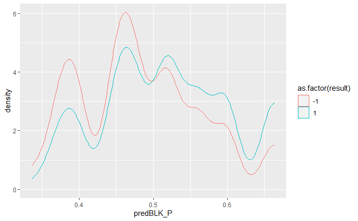

```r
ggplot(data=Cal) +
geom_density(aes(x=predBLK_P,color=as.factor(result)))
```

100 folds cross-valisation This shows that the 100-fold replicated estimate of the AUC has a mean of 0.576 and a standard deviation of 0.009. So the original of the prediction of team which is 0.579 is really good.

```r
var <- 'Team'
aucs <- rep(0,100)
for(rep in 1:length(aucs)) {
useForCalRep<-rbinom(n=nrow(TrainAll),size=1,prob=0.1)>0
predRep<-mkPredC(TrainAll[!useForCalRep,outcome],
TrainAll[!useForCalRep,var],
TrainAll[useForCalRep,var])
aucs[rep]<-calcAUC(predRep,TrainAll[useForCalRep,outcome])
}
mean(aucs)
```

```
[1] 0.5757775
```

```r
sd(aucs)
```

```
[1] 0.009415368
```

Log likelihood is a measure (a non-positive number) of how well the model’s predictions “match” the true class labels. Compute the likelihood.

```r
logLikelihood <- function(outCol,predCol) {
sum(ifelse(outCol==pos,log(predCol),log(1-predCol)))
}
baseRateCheck <-
logLikelihood(
Cal[,outcome],
sum(Cal[,outcome]==pos)/length(Cal[,outcome])
)
baseRateCheck
```

```
[1] -2522.857
```

Run through categorical variables

```r
selVars <- c()
minStep <- 5
for(v in catVars) {
pi <- paste('pred',v,sep='')
liCheck <- 2*((logLikelihood(Cal[,outcome],Cal[,pi]) - 1
- baseRateCheck))
if(liCheck>minStep) {
print(sprintf("%s, calibrationScore: %g",pi,liCheck))
selVars <- c(selVars,pi)
}
}
```

```
[1] "predTeam, calibrationScore: 76.3031"
```

Run through numerical variables

```r
for(v in numericVars) {
pi <- paste('pred',v,sep='')
liCheck <- 2*((logLikelihood(Cal[,outcome],Cal[,pi]) - 1
- baseRateCheck))
if(liCheck>=minStep) {
print(sprintf("%s, calibrationScore: %g", pi,liCheck))
selVars <- c(selVars,pi)
}
}
```

```
[1] "predFTA, calibrationScore: 39.635"
[1] "predPF, calibrationScore: 68.2645"
[1] "predAST_P, calibrationScore: 85.0097"
[1] "predDREB_P, calibrationScore: 36.8948"
[1] "predOREB_P, calibrationScore: 31.2829"
[1] "predTO_P, calibrationScore: 58.9067"
[1] "predSTL_P, calibrationScore: 80.5703"
[1] "predBLK_P, calibrationScore: 121.396"
```

Decision Tree Use Decision Tree to build a model with selected variables

```r
fV <- paste(outcome,'>0 ~ ',
paste(c(catVars,numericVars), collapse=' + '),
sep='')
tmodel <- rpart(fV,data=Train)
print(calcAUC(predict(tmodel,newdata=Train), Train[,outcome]))
```

```
[1] 0.5723801
```

```r
print(calcAUC(predict(tmodel,newdata=Test), Test[,outcome]))
```

```
[1] 0.5615978
```

```r
print(calcAUC(predict(tmodel,newdata=Cal), Cal[,outcome]))
```

```
[1] 0.579395
```

```r
tVars <- paste('pred',c(catVars,numericVars),sep='')
fV2 <- paste(outcome,'>0 ~ ',
paste(tVars,collapse=' + '),sep='')
tmodel <- rpart(fV2,data=Train)
print(calcAUC(predict(tmodel,newdata=Train), Train[,outcome]))
```

```
[1] 0.5711431
```

```r
print(calcAUC(predict(tmodel,newdata=Test), Test[,outcome]))
```

```
[1] 0.5581124
```

```r
print(calcAUC(predict(tmodel,newdata=Cal), Cal[,outcome]))
```

```
[1] 0.5791381
```

It can be seen that the decesion tree in this case is no better than a single variable model for the giving variables

```r
performanceMeasures <- function(pred, truth, name = "model") {
dev.norm <-
-2 * logLikelihood(truth, pred)/length(pred)
ctable <- table(truth = truth==pos, pred = (pred > 0.5))
accuracy <- sum(diag(ctable)) / sum(ctable)
precision <- ctable[2, 2] / sum(ctable[, 2])
recall <- ctable[2, 2] / sum(ctable[2, ])
f1 <- 2 * precision * recall / (precision + recall)
data.frame(model = name, precision = precision,
recall = recall,
f1 = f1, dev.norm = dev.norm)
}
```

Pander formatting

```r
panderOpt <- function(){
library(pander)
# setting up Pander Options
panderOptions("plain.ascii", TRUE)
panderOptions("keep.trailing.zeros", TRUE)
panderOptions("table.style", "simple")
}
```

Prettier Performance Table Function

```r
pretty_perf_table <- function(model,training,test){
# Option setting for Pander
panderOpt()
perf_justify <- "lrrrr"
# comparing performance on training vs. test
pred_train<-predict(model,newdata=training)
truth_train <- training[,outcome]
pred_test<-predict(model,newdata=test)
truth_test <- test[,outcome]
trainperf_tree <- performanceMeasures(
pred_train,truth_train,"training")
testperf_tree <- performanceMeasures(
pred_test,truth_test, "test")
perftable <- rbind(trainperf_tree, testperf_tree)
pandoc.table(perftable, justify = perf_justify)
}
```

Pretty Print of a performance table

```r
pretty_perf_table(tmodel, Train, Test)
```

```
model        precision   recall       f1   dev.norm
---------- ----------- -------- -------- ----------
training        0.5718   0.5696   0.5707      1.366
test            0.5602   0.5473   0.5537      1.373
```

It can be seen that the model has similar result for both training and test data set. However, the precesion and recall rate are generally low.

Let us plot the AUC for both traning and test data

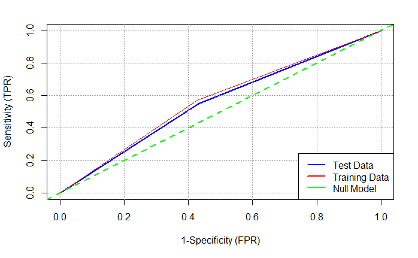

```r
library(ROCit)
plot_roc <- function(predcol1, outcol1, predcol2, outcol2){
roc_1 <- rocit(score=predcol1,class=outcol1==pos)
roc_2 <- rocit(score=predcol2,class=outcol2==pos)
plot(roc_1, col = c("blue","green"), lwd = 3,
legend = FALSE,YIndex = FALSE, values = TRUE)
lines(roc_2$TPR ~ roc_2$FPR, lwd = 1,
col = c("red","green"))
legend("bottomright", col = c("blue","red", "green"),
c("Test Data", "Training Data", "Null Model"), lwd = 2)
}
pred_test_roc<-predict(tmodel,newdata=Test)
pred_train_roc<-predict(tmodel,newdata=Train)

plot_roc(pred_test_roc, Test[[outcome]],
pred_train_roc, Train[[outcome]])
```

```r
tmodel <- rpart(fV2,data=Train,
control=rpart.control(cp=0.001,minsplit=1000,
minbucket=1000,maxdepth=5))
print(calcAUC(predict(tmodel,newdata=Train), Train[,outcome]))
```

```
[1] 0.6577161
```

```r
print(calcAUC(predict(tmodel,newdata=Test), Test[,outcome]))
```

```
[1] 0.6375633
```

```r
print(calcAUC(predict(tmodel,newdata=Cal), Cal[,outcome]))
```

```
[1] 0.6361165
```

```r
pretty_perf_table(tmodel, Train, Test)
```

```
model        precision   recall       f1   dev.norm
---------- ----------- -------- -------- ----------
training        0.6248   0.5972   0.6107      1.307
test            0.6114   0.5802   0.5954      1.326
```

Print out the structure of the decision tree

```r
print(tmodel)
```

```
n= 32885

node), split, n, deviance, yval
      * denotes terminal node

 1) root 32885 8221.2440 0.5004105
   2) predBLK_P< 0.4945741 16492 4040.9860 0.4294810
     4) predSTL_P< 0.5357903 11546 2749.6520 0.3911311
       8) predFTA< 0.4828439 5856 1289.1120 0.3271858
        16) predDREB_P< 0.539261 3693  754.4685 0.2862172
          32) predOREB_P< 0.4826709 1929  344.4894 0.2327631 *
          33) predOREB_P>=0.4826709 1764  398.4399 0.3446712 *
        17) predDREB_P>=0.539261 2163  517.8622 0.3971336 *
       9) predFTA>=0.4828439 5690 1411.9510 0.4569420
        18) predPF< 0.4375505 1204  266.0955 0.3297342 *
        19) predPF>=0.4375505 4486 1121.1430 0.4910834
          38) predTeam< 0.5096872 2678  660.1781 0.4410007 *
          39) predTeam>=0.5096872 1808  444.2987 0.5652655 *
     5) predSTL_P>=0.5357903 4946 1234.7140 0.5190053
      10) predAST_P< 0.4918619 1943  478.1523 0.4374678 *
      11) predAST_P>=0.4918619 3003  735.2854 0.5717616
        22) predTeam< 0.4880059 1302  325.4969 0.5015361 *
        23) predTeam>=0.4880059 1701  398.4527 0.6255144 *
   3) predBLK_P>=0.4945741 16393 4013.8140 0.5717684
     6) predFTA< 0.5124659 9865 2462.3760 0.5198175
      12) predSTL_P< 0.5023707 5027 1243.9670 0.4495723
        24) predDREB_P< 0.4920224 2057  474.9013 0.3616918 *
        25) predDREB_P>=0.4920224 2970  742.1764 0.5104377
          50) predAST_P< 0.4918619 1114  272.7549 0.4281867 *
          51) predAST_P>=0.4918619 1856  457.3615 0.5598060 *
      13) predSTL_P>=0.5023707 4838 1167.8300 0.5928069
        26) predDREB_P< 0.4920224 2294  573.3078 0.5091543
          52) predBLK_P< 0.5792336 1293  318.6048 0.4400619 *
          53) predBLK_P>=0.5792336 1001  240.5574 0.5984016 *
        27) predDREB_P>=0.4920224 2544  563.9937 0.6682390
          54) predTeam< 0.5042876 1175  280.3455 0.6068085 *
          55) predTeam>=0.5042876 1369  275.4083 0.7209642 *
     7) predFTA>=0.5124659 6528 1484.5800 0.6502757
      14) predPF< 0.4927711 3315  802.7644 0.5885370
        28) predAST_P< 0.4639882 1013  253.1194 0.4886476 *
        29) predAST_P>=0.4639882 2302  535.0895 0.6324935 *
      15) predPF>=0.4927711 3213  656.1425 0.7139745
        30) predTeam< 0.462949 1041  243.3852 0.6272815 *
        31) predTeam>=0.462949 2172  401.1837 0.7555249 *
```

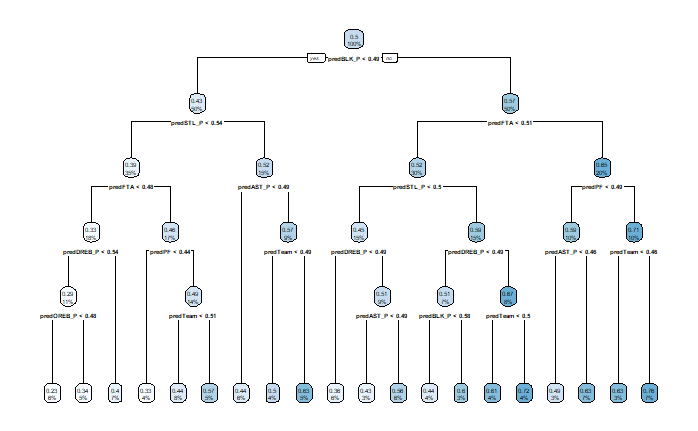

```r
par(cex=0.7)
rpart.plot(tmodel)
```

Logistic Regression Build a model with logistic regrssion. Then the AUC has been improved by 10% which is much more higher than a single varialbe model

```r
f <- paste(outcome,'>0 ~ ',paste(selVars,collapse=' + '),sep='')
gmodel <- glm(as.formula(f),data=Train,
family=binomial(link='logit'))
print(calcAUC(predict(gmodel,newdata=Train),Train[,outcome]))
```

```
[1] 0.7416939
```

```r
print(calcAUC(predict(gmodel,newdata=Test),Test[,outcome]))
```

```
[1] 0.7221605
```

```r
print(calcAUC(predict(gmodel,newdata=Cal),Cal[,outcome]))
```

```
[1] 0.7446482
```

Picking the threshold for classification

```r
train$pred <- predict(gmodel, newdata=train, type="response")
Test$pred <- predict(gmodel, newdata=Test, type="response")

predObj <- prediction(train$pred, train$result)
precObj <- performance(predObj, measure="prec")
recObj <- performance(predObj, measure="rec")
precision <- (precObj@y.values)[[1]]
prec.x <- (precObj@x.values)[[1]]
recall <- (recObj@y.values)[[1]]
rocFrame <- data.frame(threshold=prec.x,
precision=precision,
recall=recall)
pnull <-mean(as.numeric(train$result))
```

Building the plots

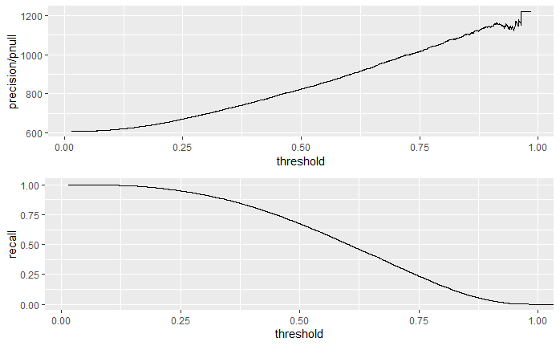

```r
p1 <- ggplot(rocFrame, aes(x=threshold)) +
geom_line(aes(y=precision/pnull)) +
coord_cartesian()
p2 <- ggplot(rocFrame, aes(x=threshold)) +
geom_line(aes(y=recall)) +
coord_cartesian()
library(gridExtra)
grid.arrange(p1,p2, nrow = 2)
```

This gives a much better predcition than that of a single a variable and decision tree

```r
ctab.test <- table(pred=Test$pred>0.5, result=Test$result)
ctab.test
```

```
       result
pred      -1    1
  FALSE 1372  685
  TRUE   660 1354
```

```r
precision <- ctab.test[2,2]/sum(ctab.test[2,])
recall <- ctab.test[2,2]/sum(ctab.test[,2])
enrich <- precision/mean(as.numeric(Test$result))
precision
```

```
[1] 0.6722939
```

```r
recall
```

```
[1] 0.664051
```

```r
enrich
```

```
[1] 390.9869
```

Building the plots of ROC curve

```r
library(ROCit)
plot_roc <- function(predcol1, outcol1, outcol2){
roc_1 <- rocit(score=predcol1,class=outcol1==pos)

plot(roc_1, col = c("blue","green"), lwd = 3,
legend = FALSE,YIndex = FALSE, values = TRUE)




legend("bottomright", col = c("blue", "green"),
c("logistic", "Null Model"), lwd = 2)
}
```

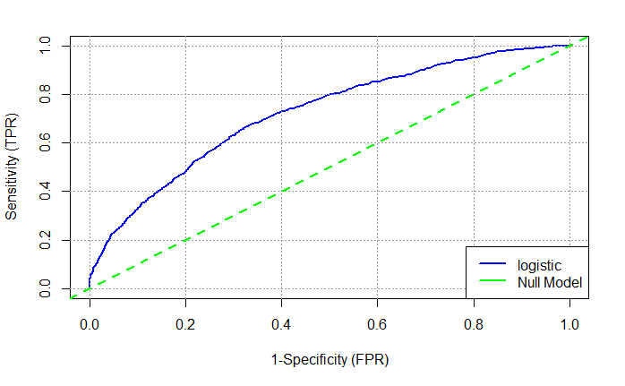

```r
pred_gmodel_roc<-predict(gmodel,newdata=Test)
plot_roc(pred_gmodel_roc, Test[[outcome]], Test[[outcome]])
```

```r
NA
NA
```

Cluster

This part is aim to get the best player seasons with score above 26 and make them into different groups to see the differece of those top players

Firstly, the data will be transformed into the format I want.

```r
players<-aggregate(nba[,c(10,11,13,14,16,17,19:27)],by=list(Players=nba$PLAYER_NAME,Year =nba$year),FUN=mean)
players<-mutate(players,TS=round(PTS*100/(2*(FGA+0.44*FTA)),3))
players<-players[which(players$PTS>26),]
players$Players<- paste(players$Players,players$Year,sep='-')
players<-players[,-2:-4]
players<-players[,-4:-5]
players$FG3P<-100*players$FG3M/players$FG3A
players <- na.omit(players)
```

Plot the result of clustering

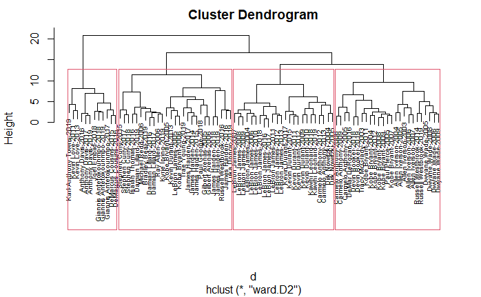

```r
vars.to.use <- colnames(players)[-1]
pmatrix <- scale(players[,vars.to.use])
pcenter <- attr(pmatrix, "scaled:center")
pscale <- attr(pmatrix, "scaled:scale")
d <- dist(pmatrix, method="euclidean")
pfit <- hclust(d, method="ward.D2")
plot(pfit, labels=players$Players,cex=0.6)
rect.hclust(pfit, k=4)
```

Define a function to print out the sorted groups

```r
groups <- cutree(pfit, k=4)
print_clusters <- function(labels, k) {
for(i in 1:k) {
print(paste("cluster", i))
print(players[labels==i,
c("Players","FG3M","FG3P","TS","PTS","REB","AST")])
}
}
print_clusters(groups, 2)
```

```
[1] "cluster 1"
```

|  | Players | FG3M | FG3P | TS | PTS | REB | AST |
| --- | --- | --- | --- | --- | --- | --- | --- |
| 9 | Allen Iverson-2003 | 1.1875000 | 28.64322 | 47.766 | 26.37500 | 3.708333 | 6.750000 |
| 409 | Tracy McGrady-2003 | 2.5970149 | 33.91813 | 52.576 | 28.02985 | 6.000000 | 5.522388 |
| 453 | Allen Iverson-2004 | 1.3866667 | 30.76923 | 53.192 | 30.69333 | 3.986667 | 7.946667 |
| 699 | Kobe Bryant-2004 | 1.9848485 | 33.85013 | 56.275 | 27.56061 | 5.939394 | 6.030303 |
| 918 | Allen Iverson-2005 | 1.0000000 | 32.28700 | 54.350 | 33.01389 | 3.222222 | 7.388889 |
| 981 | Carmelo Anthony-2005 | 0.4625000 | 24.34211 | 56.318 | 26.52500 | 4.925000 | 2.700000 |
| 1049 | Dwyane Wade-2005 | 0.1733333 | 17.10526 | 57.747 | 27.20000 | 5.733333 | 6.706667 |
| 1252 | Paul Pierce-2005 | 1.4050633 | 35.35032 | 58.155 | 26.78481 | 6.708861 | 4.746835 |
| 1376 | Allen Iverson-2006 | 0.9538462 | 31.47208 | 54.034 | 26.29231 | 2.969231 | 7.200000 |
| 1431 | Carmelo Anthony-2006 | 0.6153846 | 26.84564 | 55.229 | 28.93846 | 6.015385 | 3.830769 |

[output cut: 15 more lines]

```
[1] "cluster 2"
```

|  | Players | FG3M | FG3P | TS | PTS | REB | AST |
| --- | --- | --- | --- | --- | --- | --- | --- |
| 569 | Dirk Nowitzki-2004 | 1.1666667 | 39.91228 | 57.842 | 26.05128 | 9.705128 | 3.076923 |
| 711 | LeBron James-2004 | 1.3500000 | 35.06494 | 55.376 | 27.18750 | 7.350000 | 7.212500 |
| 1039 | Dirk Nowitzki-2005 | 1.3580247 | 40.59041 | 58.863 | 26.55556 | 8.987654 | 2.790123 |
| 1626 | LeBron James-2006 | 1.2692308 | 31.93548 | 55.249 | 27.33333 | 6.743590 | 6.025641 |
| 2087 | LeBron James-2007 | 1.5066667 | 31.47632 | 56.783 | 30.00000 | 7.893333 | 7.186667 |
| 2529 | LeBron James-2008 | 1.6296296 | 34.37500 | 59.129 | 28.44444 | 7.567901 | 7.246914 |
| 2958 | Kevin Durant-2009 | 1.5609756 | 36.46724 | 60.660 | 30.14634 | 7.597561 | 2.817073 |
| 2978 | LeBron James-2009 | 1.6973684 | 33.33333 | 60.435 | 29.71053 | 7.289474 | 8.565789 |
| 3409 | Kevin Durant-2010 | 1.8589744 | 35.02415 | 58.883 | 27.70513 | 6.833333 | 2.743590 |
| 3433 | LeBron James-2010 | 1.1645570 | 32.97491 | 59.407 | 26.72152 | 7.468354 | 7.012658 |

[output cut: 14 more lines]

Plot the result of clustering

```r
library(ggplot2)
# Calculate the principle components of pmatrix
princ <- prcomp(pmatrix)
nComp <- 2
project <- as.data.frame(predict(princ, newdata=pmatrix)[,1:nComp])
project.plus <-
cbind(project,
cluster=as.factor(groups),
country=players$Players)
```

finding convex hull

```r
library('grDevices')
h <- do.call(
rbind,
lapply(
unique(groups),
function(c) {
f <- subset(project.plus,cluster==c);
f[chull(f),]
}
)
)
```

Visualising Cluster

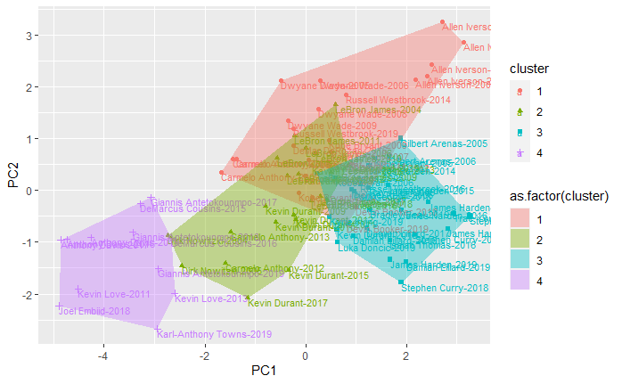

```r
p <- ggplot(project.plus, aes(x=PC1, y=PC2)) +
geom_point(aes(shape=cluster, color=cluster)) +
geom_text(aes(label=country, color=cluster),
hjust=0, vjust=1, size=3) +
geom_polygon(data=h,
aes(group=cluster,
fill=as.factor(cluster)),
alpha=0.4,linetype=0)
p
```

```r
library(fpc)
kbest.p <- 4
cboot.hclust <- clusterboot(
pmatrix, clustermethod=hclustCBI,
method="ward.D2", k=kbest.p)
```

Summary of clusterboot result

```r
summary(cboot.hclust$result)
```

```
              Length Class  Mode
result         7     hclust list
noise          1     -none- logical
nc             1     -none- numeric
clusterlist    4     -none- list
partition     88     -none- numeric
clustermethod  1     -none- character
nccl           1     -none- numeric
```

```r
groups <- cboot.hclust$result$partition
print_clusters(groups, 4)
```

```
[1] "cluster 1"
```

|  | Players | FG3M | FG3P | TS | PTS | REB | AST |
| --- | --- | --- | --- | --- | --- | --- | --- |
| 9 | Allen Iverson-2003 | 1.1875000 | 28.64322 | 47.766 | 26.37500 | 3.708333 | 6.750000 |
| 409 | Tracy McGrady-2003 | 2.5970149 | 33.91813 | 52.576 | 28.02985 | 6.000000 | 5.522388 |
| 453 | Allen Iverson-2004 | 1.3866667 | 30.76923 | 53.192 | 30.69333 | 3.986667 | 7.946667 |
| 699 | Kobe Bryant-2004 | 1.9848485 | 33.85013 | 56.275 | 27.56061 | 5.939394 | 6.030303 |
| 918 | Allen Iverson-2005 | 1.0000000 | 32.28700 | 54.350 | 33.01389 | 3.222222 | 7.388889 |
| 981 | Carmelo Anthony-2005 | 0.4625000 | 24.34211 | 56.318 | 26.52500 | 4.925000 | 2.700000 |
| 1049 | Dwyane Wade-2005 | 0.1733333 | 17.10526 | 57.747 | 27.20000 | 5.733333 | 6.706667 |
| 1252 | Paul Pierce-2005 | 1.4050633 | 35.35032 | 58.155 | 26.78481 | 6.708861 | 4.746835 |
| 1376 | Allen Iverson-2006 | 0.9538462 | 31.47208 | 54.034 | 26.29231 | 2.969231 | 7.200000 |
| 1431 | Carmelo Anthony-2006 | 0.6153846 | 26.84564 | 55.229 | 28.93846 | 6.015385 | 3.830769 |

[output cut: 15 more lines]

```
[1] "cluster 2"
```

|  | Players | FG3M | FG3P | TS | PTS | REB | AST |
| --- | --- | --- | --- | --- | --- | --- | --- |
| 569 | Dirk Nowitzki-2004 | 1.1666667 | 39.91228 | 57.842 | 26.05128 | 9.705128 | 3.076923 |
| 711 | LeBron James-2004 | 1.3500000 | 35.06494 | 55.376 | 27.18750 | 7.350000 | 7.212500 |
| 1039 | Dirk Nowitzki-2005 | 1.3580247 | 40.59041 | 58.863 | 26.55556 | 8.987654 | 2.790123 |
| 1626 | LeBron James-2006 | 1.2692308 | 31.93548 | 55.249 | 27.33333 | 6.743590 | 6.025641 |
| 2087 | LeBron James-2007 | 1.5066667 | 31.47632 | 56.783 | 30.00000 | 7.893333 | 7.186667 |
| 2529 | LeBron James-2008 | 1.6296296 | 34.37500 | 59.129 | 28.44444 | 7.567901 | 7.246914 |
| 2958 | Kevin Durant-2009 | 1.5609756 | 36.46724 | 60.660 | 30.14634 | 7.597561 | 2.817073 |
| 2978 | LeBron James-2009 | 1.6973684 | 33.33333 | 60.435 | 29.71053 | 7.289474 | 8.565789 |
| 3409 | Kevin Durant-2010 | 1.8589744 | 35.02415 | 58.883 | 27.70513 | 6.833333 | 2.743590 |
| 3433 | LeBron James-2010 | 1.1645570 | 32.97491 | 59.407 | 26.72152 | 7.468354 | 7.012658 |

[output cut: 14 more lines]

```
[1] "cluster 3"
```

|  | Players | FG3M | FG3P | TS | PTS | REB | AST |
| --- | --- | --- | --- | --- | --- | --- | --- |
| 1078 | Gilbert Arenas-2005 | 2.487500 | 36.85185 | 58.082 | 29.32500 | 3.500000 | 6.050000 |
| 1164 | Kobe Bryant-2005 | 2.250000 | 34.74903 | 55.894 | 35.40000 | 5.312500 | 4.500000 |
| 1175 | LeBron James-2005 | 1.607595 | 33.50923 | 56.805 | 31.36709 | 7.037975 | 6.594937 |
| 1527 | Gilbert Arenas-2006 | 2.770270 | 35.10274 | 56.467 | 28.44595 | 4.567568 | 5.986486 |
| 1615 | Kobe Bryant-2006 | 1.779221 | 34.42211 | 57.997 | 31.55844 | 5.701299 | 5.363636 |
| 1671 | Michael Redd-2006 | 2.207547 | 38.23529 | 58.607 | 26.71698 | 3.698113 | 2.339623 |
| 1725 | Ray Allen-2006 | 3.000000 | 37.24605 | 56.402 | 26.43636 | 4.490909 | 4.145455 |
| 4822 | Kevin Durant-2013 | 2.370370 | 39.10387 | 63.485 | 32.01235 | 7.382716 | 5.493827 |
| 5233 | James Harden-2014 | 2.567901 | 37.47748 | 60.489 | 27.37037 | 5.666667 | 6.975309 |
| 5713 | James Harden-2015 | 2.878049 | 35.92085 | 59.840 | 28.97561 | 6.109756 | 7.463415 |

[output cut: 17 more lines]

```
[1] "cluster 4"
```

|  | Players | FG3M | FG3P | TS | PTS | REB | AST |
| --- | --- | --- | --- | --- | --- | --- | --- |
| 3891 | Kevin Love-2011 | 1.9090909 | 37.23404 | 56.762 | 26.03636 | 13.345455 | 2.018182 |
| 4824 | Kevin Love-2013 | 2.4675325 | 37.62376 | 59.134 | 26.10390 | 12.506494 | 4.428571 |
| 5640 | DeMarcus Cousins-2015 | 1.0769231 | 33.33333 | 53.827 | 26.89231 | 11.492308 | 3.292308 |
| 6034 | Anthony Davis-2016 | 0.5333333 | 29.85075 | 57.962 | 27.98667 | 11.786667 | 2.093333 |
| 6117 | DeMarcus Cousins-2016 | 1.8194444 | 36.08815 | 56.231 | 26.97222 | 11.027778 | 4.611111 |
| 6521 | Anthony Davis-2017 | 0.7333333 | 33.95062 | 61.155 | 28.13333 | 11.080000 | 2.320000 |
| 6666 | Giannis Antetokounmpo-2017 | 0.5733333 | 30.71429 | 59.797 | 26.85333 | 10.040000 | 4.813333 |
| 7211 | Giannis Antetokounmpo-2018 | 0.7222222 | 25.61576 | 64.371 | 27.69444 | 12.472222 | 5.888889 |
| 7289 | Joel Embiid-2018 | 1.2343750 | 30.03802 | 59.311 | 27.51562 | 13.609375 | 3.656250 |
| 7584 | Anthony Davis-2019 | 1.0980392 | 32.36994 | 61.091 | 26.35294 | 9.411765 | 3.254902 |

[output cut: 2 more lines]

count of how many times each cluster was dissolved So the group 4 has the highest table and group 1 and 3 is OK, but the group 2 is the lowest which is unstable.

```r
1-cboot.hclust$bootbrd/100
```

```
[1] 0.77 0.42 0.56 0.98
```

Selecting K

```r
sqr_edist <- function(x, y) {
sum((x-y)^2)
}

wss.cluster <- function(clustermat) {
c0 <- apply(clustermat, 2, FUN=mean)
sum(apply(clustermat, 1,
FUN=function(row){sqr_edist(row,c0)}))
}


wss.total <- function(dmatrix, labels) {
wsstot <- 0
k <- length(unique(labels))
for(i in 1:k){
wsstot <- wsstot +
wss.cluster(subset(dmatrix, labels==i))
}
wsstot
}
```

```r
totss <- function(dmatrix) {
grandmean <- apply(dmatrix, 2, FUN=mean)
sum(apply(dmatrix, 1,
FUN=function(row){
sqr_edist(row, grandmean)
}
)
)
}
```

```r
ch_criterion <- function(dmatrix, kmax, method="kmeans") {
if(!(method %in% c("kmeans", "hclust"))){
stop("method must be one of c('kmeans', 'hclust')")
}
npts <- dim(dmatrix)[1] # number of rows.
totss <- totss(dmatrix)
wss <- numeric(kmax)
crit <- numeric(kmax)
wss[1] <- (npts-1)*sum(apply(dmatrix, 2, mean))
for(k in 2:kmax) {
if(method=="kmeans") {
clustering<-kmeans(dmatrix, k, nstart=10, iter.max=100)
wss[k] <- clustering$tot.withinss
}else { # hclust
d <- dist(dmatrix, method="euclidean")
pfit <- hclust(d, method="ward.D2")
labels <- cutree(pfit, k=k)
wss[k] <- wss.total(dmatrix, labels)
}
}
bss <- totss - wss
crit.num <- bss/(0:(kmax-1))
crit.denom <- wss/(npts - 1:kmax)
list(crit = crit.num/crit.denom, wss = wss, totss = totss)
}
```

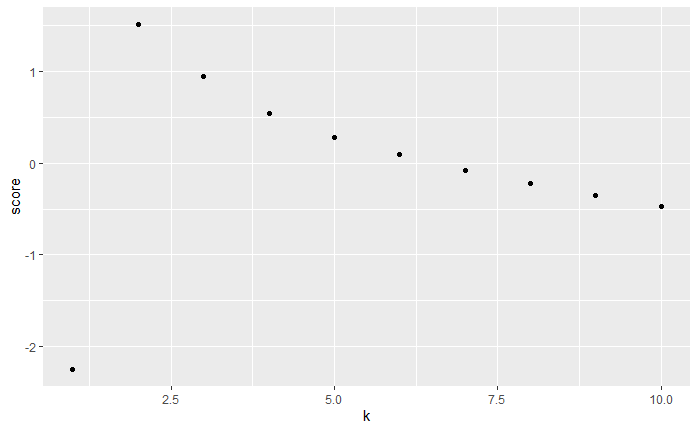

```r
library(reshape2)
clustcrit <- ch_criterion(pmatrix, 10, method="hclust")
critframe <- data.frame(k=1:10, ch=scale(clustcrit$crit),
wss=scale(clustcrit$wss))
critframe <- melt(critframe, id.vars=c("k"),
variable.name="measure",
value.name="score")
p<-ggplot(critframe, aes(x=k, y=score)) +
geom_point()
p
```